# ASS22

Chih-Yu

2024-03-08

# Question 1 (3.1)

## a. 2 dimension

[figure not shown]

## b.3 dimension

deviation vector

```r
x <- matrix(c(9,1,5,3,1,2), nrow=3, byrow=TRUE)
devivation <- x-matrix(c(1,1,1))%*%colMeans(x)
devivation
```

```
##      [,1] [,2]
## [1,]    4   -1
## [2,]    0    1
## [3,]   -4    0
```

[figure not shown]

## c. length and cosine of deviation vectors

```r
length_1 <- sqrt(sum(devivation[,1]^2))
length_2 <- sqrt(sum(devivation[,2]^2))
length_1
```

```
## [1] 5.656854
```

```r
length_2
```

```
## [1] 1.414214
```

```r
R = cor(x)
R
```

```
##      [,1] [,2]
## [1,]  1.0 -0.5
## [2,] -0.5  1.0
```

Length of d1 = 5.656854, Length of d2 = 1.414214

We have cosin(d1,d2)=R12 with R is sample correlation coefficient so cosin(d1,d2) is: R12 = -0.5

# Question 2 (3.2)

## a. 2 dimension

```r
x <- matrix(c(3,4,6,-2,3,1), nrow=3, byrow=TRUE)
x
```

```
##      [,1] [,2]
## [1,]    3    4
## [2,]    6   -2
## [3,]    3    1
```

```r
colMeans(x)
```

```
## [1] 4 1
```

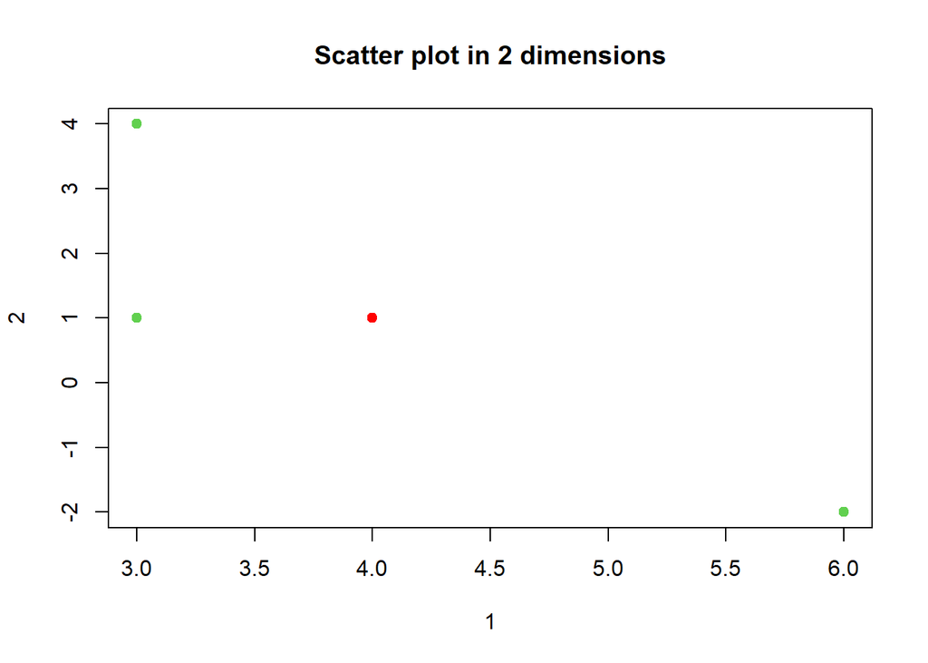

```r
plot(x,pch=19,col=3,main = "Scatter plot in 2 dimensions",xlab="1",ylab="2")
points(4,1,col="red",pch=19)
```

## b.3dimension

```r
devivation <- x-matrix(c(1,1,1))%*%colMeans(x)
devivation
```

```
##      [,1] [,2]
## [1,]   -1    3
## [2,]    2   -3
## [3,]   -1    0
```

[figure not shown]

## c. length and cosine of deviation vectors

```r
length_1 <- sqrt(sum(devivation[,1]^2))
length_2 <- sqrt(sum(devivation[,2]^2))
length_1
```

```
## [1] 2.44949
```

```r
length_2
```

```
## [1] 4.242641
```

```r
R = cor(x)
R
```

```
##            [,1]       [,2]
## [1,]  1.0000000 -0.8660254
## [2,] -0.8660254  1.0000000
```

Length of d1 = 2.4494897, Length of d2 = 4.2426407

We have cosin(d1,d2)=R12 with R is sample correlation coefficient so cosin(d1,d2) is: R12 = -0.8660254

# Question 3 (3.3)

[figure not shown]

# Question 4 (3.4)

## a) projection

```r
library(MATH4793CHUAssignment)
T1_1$V1
```

```
## [1] 3497900 2485475 1782875 1725450 1645575 1469800
```

```r
T1_1$V1 - matrix(c(1,1,1,1,1,1))%*%colMeans(T1_1)
```

```
##           [,1]    [,2]
## [1,] 1396720.8 3497899
## [2,]  384295.8 2485474
## [3,] -318304.2 1782874
## [4,] -375729.2 1725449
## [5,] -455604.2 1645574
## [6,] -631379.2 1469799
```

# Question 5 (3.5)

```r
x1 <- matrix(c(9,1,5,3,1,2), nrow=3, byrow=TRUE)
cov(x1)
```

```
##      [,1] [,2]
## [1,]   16   -2
## [2,]   -2    1
```

```r
det(cov(x1))
```

```
## [1] 12
```

```r
x2 <- matrix(c(3,4,6,-2,3,1), nrow=3, byrow=TRUE)
cov(x2)
```

```
##      [,1] [,2]
## [1,]  3.0 -4.5
## [2,] -4.5  9.0
```

```r
det(cov(x2))
```

```
## [1] 6.75
```

# Question 6 (3.6)

## a. deviation

```r
x <- matrix(c(-1,3,-2,2,4,2,5,2,3), nrow=3, byrow=TRUE)
x
```

```
##      [,1] [,2] [,3]
## [1,]   -1    3   -2
## [2,]    2    4    2
## [3,]    5    2    3
```

```r
deviation <- x - matrix(c(1,1,1))%*%colMeans(x)
deviation
```

```
##      [,1] [,2] [,3]
## [1,]   -3    0   -3
## [2,]    0    1    1
## [3,]    3   -1    2
```

```r
a=deviation%*%matrix(c(1,1,-1),ncol = 1)
a
```

```
##      [,1]
## [1,]    0
## [2,]    0
## [3,]    0
```

## b. S and generalized sample variance

```r
# Sample Variance-Covariance Matrix S
S <- cov(x)
S
```

```
##      [,1] [,2] [,3]
## [1,]  9.0 -1.5  7.5
## [2,] -1.5  1.0 -0.5
## [3,]  7.5 -0.5  7.0
```

```r
det(S)
```

```
## [1] 5.995204e-15
```

The determine of S is close to 0 (consider as 0). This suggest that there is a least one dependent column in the data. In other words, the matrix is not full rank. The result is same as part a.

## c. total sample variance

```r
sum(diag(S))
```

```
## [1] 17
```

# Question 7 (3.7)

```r
A <- matrix(c(5,4,4,5), nrow = 2, byrow=TRUE)
B <- matrix(c(5,-4,-4,5), nrow = 2, byrow=TRUE)
C <- matrix(c(3,0,0,3), nrow = 2, byrow=TRUE)
eigen(A)
```

```
## eigen() decomposition
## $values
## [1] 9 1
##
## $vectors
##           [,1]       [,2]
## [1,] 0.7071068 -0.7071068
## [2,] 0.7071068  0.7071068
```

```r
acos(0.7071068)*(180/pi)
```

```
## [1] 45
```

```r
eigen(B)
```

```
## eigen() decomposition
## $values
## [1] 9 1
##
## $vectors
##            [,1]       [,2]
## [1,] -0.7071068 -0.7071068
## [2,]  0.7071068 -0.7071068
```

```r
acos(-0.7071068)*(180/pi)
```

```
## [1] 135
```

```r
eigen(C)
```

```
## eigen() decomposition
## $values
## [1] 3 3
##
## $vectors
##      [,1] [,2]
## [1,]    0   -1
## [2,]    1    0
```

```r
acos(0)*(180/pi)
```

```
## [1] 90
```

[figure not shown]

# Question 8 (3.8)

```r
S1 <- matrix(c(1, 0, 0,
               0, 1, 0,
               0, 0, 1), nrow = 3, byrow = TRUE)

S2 <- matrix(c(1, -1/2, -1/2,
               -1/2, 1, -1/2,
               -1/2, -1/2, 1), nrow = 3, byrow = TRUE)
```

## a.toal sample variance

```r
variance1 <- sum(diag(S1))
variance2 <- sum(diag(S2))
variance1
```

```
## [1] 3
```

```r
variance2
```

```
## [1] 3
```

S1 and S2 have the sample total sample variance

## b. generalize sample variance

```r
det(S1)
```

```
## [1] 1
```

```r
det(S2)
```

```
## [1] 0
```

For S1, since its generalize sample variance = 1, it mean that the column are independent to each other. For S2, since its generalize sample variance = 0, it mean that the column is not completely independence, at least one is dependent

# Question 9 (3.9)

# Question 10 (3.10)

# Question 11 (3.11)

# Question 12 (3.12)

# Question 13 (3.13)

# Question 14 (3.14)

# Question 15 (3.15)

# Question 16 (4.1)

[figure not shown]

# Question 17 (4.2)